# Response and adverse events to chemotherapy: A mock study

Alison Hill, Ph.D.

1

Peter Higgins, MD, Ph.D.

2

Daniel Chen, MPH

3

# 1 Title Page

Title: A Mock Randomized Trial of Three Chemotherapy Regimens for Cholangiocarcinoma

Authors: Author One1, Author Two2, Author Three3

Affiliations: 1. University of Academia, Department of Oncology 2. University of Academia, Department of Pathology 3. University of Academia, Department of Statistics

Corresponding Author: Author One, MD University of Academia 123 Elm Street City, State, 12345 USA

Tel: 555-555-1234 Fax: 555-555-7890 Email: author_one@uacademia.edu

Running Title: Mock Chemotherapy for Cholangiocarcinoma Word Count: 1805

# 2 Abstract

BACKGROUND There is no established standard chemotherapy for participants with locally advanced or metastatic cholangiocarcinoma. Published case series have suggested benefits from FOLFOX, IRL, and IROX regimens.

# 3 Introduction

Cholangiocarcinoma is an uncommon cancer in developed countries. There are approximately 9000 new cases in the United States per year, although the incidence is increasing, perhaps related to gallstone disease or environmental factors. Most patients have advanced disease at presentation and relapse despite surgery, with a high 5-year mortality. Although advanced cholangiocarcinoma can have a response to chemotherapy, there is no recognized standard palliative regimen because no single randomized study has ever been sufficiently robust to define a schedule; FOLFOX, IROX, and IRL regimens have shown activity in case series.

We previously found an improvement in 6-month progression-free survival from 47.7% to 57.1% in a randomized, phase 2 mock trial (the XYZ-01 trial) comparing FOLFOX to IRL; that trial involved 86 participants. That study was extended and expanded to become a three-arm phase 3 mock trial (the XYZ-02 trial) with a planned recruitment total of 1500 participants at 13 sites and a primary end point of overall survival.

# 4 Methods

## 4.1 STUDY DESIGN

This randomized, double-blind, active therapy-controlled, phase 3 mock trial was designed and developed by the XYZ-02 Trial Management Group under the auspices of the Academia University Cancer Research Institute. The study was conducted by investigators at 13 centers around the world, and data were collected and analyzed at the Academia University Cancer Trials Center. The trial was initially designed as a randomized, phase 2 study involving 86 participants (the XYZ-01 trial), conducted between February 2002 and June 2004. The trial was extended and expanded into a phase 3 trial (the XYZ-02 trial) because of an apparent benefit in progression-free survival; this extension used a similar approach to that described previously. The same treatment regimens (plus the addition of IROX) and eligibility criteria were used in both phases. Investigators were unaware of the overall survival analysis in the XYZ-01 trial, as mandated by the independent data and safety monitoring committee.

This trial was approved by a research ethics committee, and all necessary regulatory approvals were obtained. All participants were required to give written informed consent before randomization, and the trial was conducted in accordance with the Declaration of Helsinki. An independent data and safety monitoring board regularly reviewed the data on safety.

The Ipsen Group provided the investigators with irinotectan liposome injection (Onivyde) at no cost but was not involved in the accrual or analysis of the data, the interpretation of the results, or the preparation of the manuscript.

## 4.2 PARTICIPANTS

Mock participants were eligible for the study if they were 18 years of age or older and had received a histopathological or cytologic diagnosis of nonresectable, recurrent, or metastatic cholangiocarcinoma; an Eastern Cooperative Oncology Group (ECOG) performance status of 0, 1, or 2 (on a scale ranging from 0 to 5, with lower scores indicating a higher level of functioning); and an estimated life expectancy of more than 3 months. Other eligibility criteria were adequate hematologic and biochemical function, in particular a total bilirubin level of 1.5 times the upper limit of the normal range or less, liver-enzyme levels that were five times the upper limit of the normal range or less, renal function with levels of serum urea and serum creatinine that were less than 1.5 times the upper limit of the normal range, and a calculated glomerular filtration rate of 45 ml per minute or higher.

## 4.4 ASSESSMENTS

Participants were seen at the start of every cycle for a physical examination, monitoring of symptoms and toxic effects, assessment of renal function, and a complete blood count. Tumor response, measured according to the Response Evaluation Criteria in Solid Tumors (RECIST) 1.0 criteria, was assessed by means of computed tomography (CT) or magnetic resonance imaging (MRI) at week 12 and again at week 24 in participants who completed treatment (confirmatory scans were not required). After the end of the study treatment, participants were seen in the clinic every 3 months. Follow-up visits consisted of clinical assessment and either CT or MRI to assess tumor progression. Once progressive disease was documented, participants underwent follow-up for survival only.

## 4.5 STATISTICAL ANALYSIS

Participants were randomly assigned by telephone by the University of Academia Cancer Trials Centre, which coordinated the trial. Randomization was conducted with the use of a minimization algorithm stratified according to the extent of disease (locally advanced vs. metastatic), performance status, previous therapy, and recruiting center. All analyses were performed on an intention-to-treat basis. Overall survival was calculated from the date of randomization until the date of death. Participants who did not have disease progression and participants who died were excluded at the date of their last follow-up. Overall survival was analyzed with the use of Kaplan–Meier curves and the log-rank test. A Cox proportional-hazards model was used to estimate the hazard ratios. Toxic effects were categorized according to the National Cancer Institute’s Common Toxicity Criteria for Adverse Events, version 3.

All analyses were performed with the use of R software (R Foundation for Statistical Computing, Vienna, Austria. URL https://www.R-project.org/) and the R packages tidyverse, janitor, gt, and flextable. The mock database was closed for analysis in June 2009.

## 4.6 DATA AND CODE REPOSITORIES

The raw data and code from this analysis have been deposited at https://osf.io/xcbe4/ and the original draft manuscript can be found as a preprint at MedRxiv at https://www.medrxiv.org/content/10.1101/19004762v2. A durable research compendium made with the holepunch package, including the appropriate versions of R and R packages, along with data and code to run the complete analysis, can be found at https://github.com/karthik/binder-test.

# 5 Results

## 5.1 Demographics

Baseline characteristics were well balanced between the three treatment groups (Table 1).

|  | A: IFL (N=428) | F: FOLFOX (N=676) | G: IROX (N=380) | Total (N=1484) | p value |
| --- | --- | --- | --- | --- | --- |
| **Gender** |  |  |  |  | 0.22<sup>1</sup> |
| Female | 151 (35.3%) | 272 (40.2%) | 152 (40.0%) | 575 (38.7%) |  |
| Male | 277 (64.7%) | 404 (59.8%) | 228 (60.0%) | 909 (61.3%) |  |
| **Race** |  |  |  |  | 0.23<sup>1</sup> |
| African-Am | 39 (9.1%) | 49 (7.2%) | 27 (7.1%) | 115 (7.7%) |  |
| Asian | 1 (0.2%) | 14 (2.1%) | 3 (0.8%) | 18 (1.2%) |  |
| Caucasian | 371 (86.7%) | 574 (84.9%) | 331 (87.1%) | 1276 (86.0%) |  |
| Hawaii/Pacific | 1 (0.2%) | 3 (0.4%) | 1 (0.3%) | 5 (0.3%) |  |
| Hispanic | 12 (2.8%) | 26 (3.8%) | 14 (3.7%) | 52 (3.5%) |  |
| Native-Am/Alaska | 2 (0.5%) | 1 (0.1%) | 2 (0.5%) | 5 (0.3%) |  |
| Other | 2 (0.5%) | 9 (1.3%) | 2 (0.5%) | 13 (0.9%) |  |
| **Age, years** |  |  |  |  | 0.67<sup>2</sup> |
| Mean (SD) | 59.7 (11.4) | 60.3 (11.6) | 59.8 (11.5) | 60.0 (11.5) |  |
| Range | 27.0 - 88.0 | 19.0 - 88.0 | 26.0 - 85.0 | 19.0 - 88.0 |  |
| **Body Mass Index (kg/m2)** |  |  |  |  | 0.89<sup>2</sup> |
| N-Miss | 9 | 19 | 4 | 32 |  |
| Mean (SD) | 27.3 (5.6) | 27.2 (5.2) | 27.1 (5.8) | 27.2 (5.4) |  |
| Range | 14.1 - 53.0 | 16.6 - 49.1 | 15.4 - 60.2 | 14.1 - 60.2 |  |

1. Pearson’s Chi-squared test
2. Linear Model ANOVA

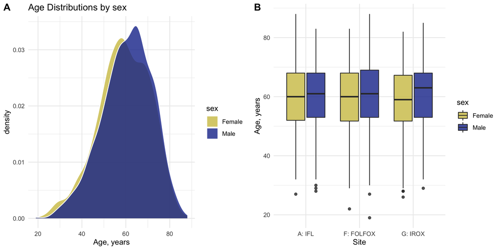

## 5.2 Treatment Response

|  | A: IFL (N=428) | F: FOLFOX (N=676) | G: IROX (N=380) | Total (N=1484) | p value |
| --- | --- | --- | --- | --- | --- |
| **Vital Status** |  |  |  |  | < 0.01<sup>1</sup> |
| Lived | 18 (4.2%) | 96 (14.2%) | 26 (6.8%) | 140 (9.4%) |  |
| Died | 410 (95.8%) | 580 (85.8%) | 354 (93.2%) | 1344 (90.6%) |  |
| **Follow-up (days)** |  |  |  |  | < 0.01<sup>2</sup> |
| Median | 446 | 600 | 516 | 542 |  |
| Q1, Q3 | 256, 724 | 348, 1046 | 306, 807 | 310, 878 |  |

1. Pearson’s Chi-squared test
2. Linear Model ANOVA

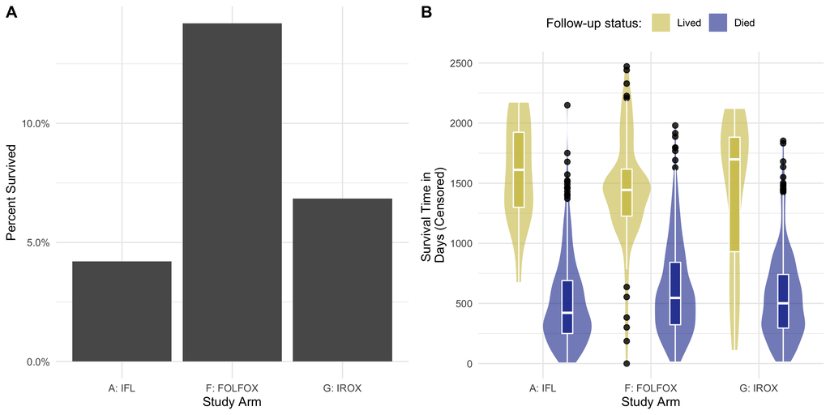

## 5.3 Survival Analysis

|  | Female (N=575) | Male (N=909) | Total (N=1484) | p value |
| --- | --- | --- | --- | --- |
| **Surv(fu_time, fu_stat)** |  |  |  | 0.928 |
| Events | 521 | 823 | 1344 |  |
| Median Survival | 543.00 | 550.00 | 546.00 |  |

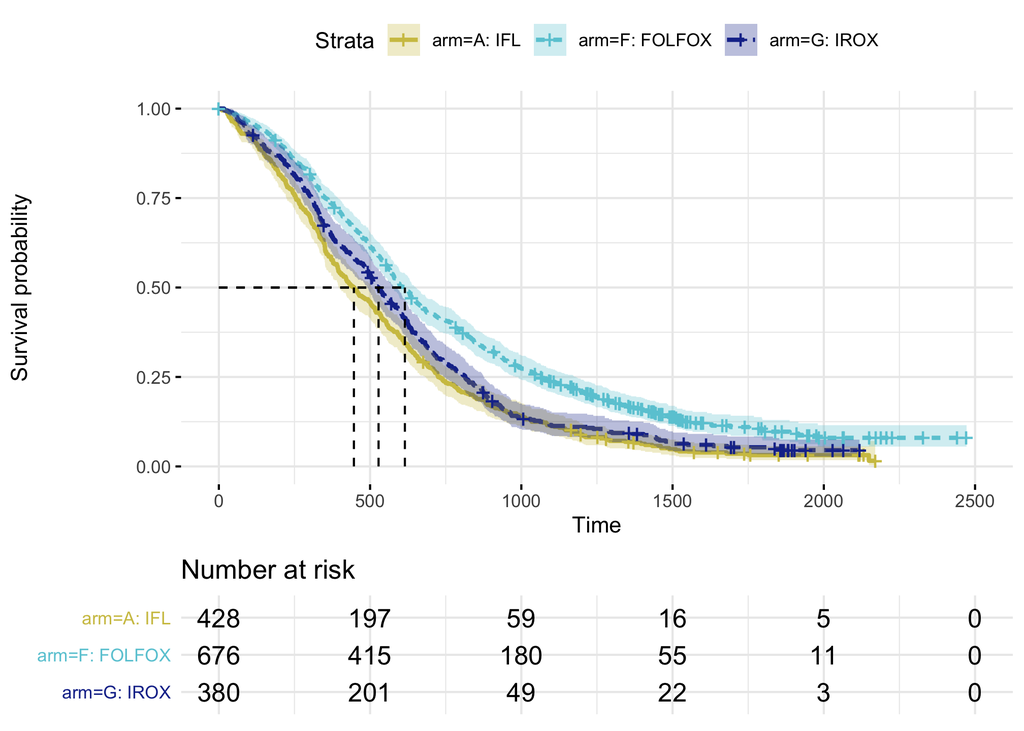

## 5.4 Adverse Events

|  | A: IFL (N=428) | F: FOLFOX (N=676) | G: IROX (N=380) | Total (N=1484) | p value |
| --- | --- | --- | --- | --- | --- |
| **ae_blood_clot** |  |  |  |  | 0.84<sup>1</sup> |
| 0 | 409 (95.6%) | 649 (96.0%) | 362 (95.3%) | 1420 (95.7%) |  |
| 1 | 19 (4.4%) | 27 (4.0%) | 18 (4.7%) | 64 (4.3%) |  |
| **ae_vomiting** |  |  |  |  | < 0.01<sup>1</sup> |
| 0 | 346 (80.8%) | 538 (79.6%) | 336 (88.4%) | 1220 (82.2%) |  |
| 1 | 82 (19.2%) | 138 (20.4%) | 44 (11.6%) | 264 (17.8%) |  |
| **ae_diarrhea** |  |  |  |  | < 0.01<sup>1</sup> |
| 0 | 346 (80.8%) | 510 (75.4%) | 336 (88.4%) | 1192 (80.3%) |  |
| 1 | 82 (19.2%) | 166 (24.6%) | 44 (11.6%) | 292 (19.7%) |  |
| **ae_neuropathy** |  |  |  |  | < 0.01<sup>1</sup> |
| 0 | 360 (84.1%) | 557 (82.4%) | 344 (90.5%) | 1261 (85.0%) |  |
| 1 | 68 (15.9%) | 119 (17.6%) | 36 (9.5%) | 223 (15.0%) |  |
| **ae_low_wbc** |  |  |  |  | < 0.01<sup>1</sup> |
| 0 | 360 (84.1%) | 518 (76.6%) | 344 (90.5%) | 1222 (82.3%) |  |
| 1 | 68 (15.9%) | 158 (23.4%) | 36 (9.5%) | 262 (17.7%) |  |

1. Pearson’s Chi-squared test

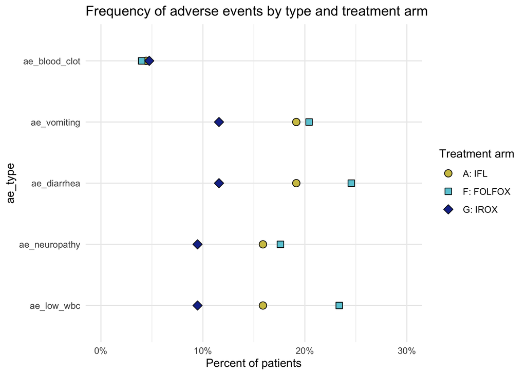

# 6 Citations